# Contents

- Introduction
- Data Preprocessing
- Exploratory Analysis
- Examining Methods of Discovery
- Relating Stars and Planets
- Conclusions

# Introduction

[Exoplanets](https://en.wikipedia.org/wiki/Exoplanet) (planets outside our solar system) are an object of great interest in astronomy, both to scientists and the general public. Many science fiction works explore the possibility of life on these planets, and some consider that we may one day be able to colonize new habitable worlds. On the science side, exoplanets provide insight into how our own solar system was formed, as well as clues about the abundance (or lack thereof) of certain elements within the universe.

Various search efforts have been undertaken to detect exoplanets. The [Kepler space telescope](https://en.wikipedia.org/wiki/Kepler_space_telescope) was one of the most successful efforts that managed to identify over 2500 exoplanets. The [Wide Angle Search for Planets (WASP)](https://en.wikipedia.org/wiki/Wide_Angle_Search_for_Planets) is an international initiative that uses telescopes accross the globe to observe stars for signs of exoplanets. Other projects include TESS, UKIRT, HATNet, and CoRoT, just to name a few.

For this project, I have chosen to use data from the [NASA Exoplanet Archive](https://exoplanetarchive.ipac.caltech.edu), which aggregates data from many exoplanet searching projects into a comprehensive list of exoplanets, their properties, and information about the systems in which they reside. This cumulative data includes an entry for each time a publication is made on an exoplanet. This means that if a planet is measured multiple times or through different methods, the data for each is available. I found this data useful for its comprehensive nature, and in this project, I will use it to examine the strengths and weaknesses of different detection methods, as well as the relationship between exoplanets and their host stars.

# Data Preprocessing

First, I need to load the data and relevant libraries and examine the columns of the dataset. Because this dataset has 286 columns, I will exclude column descriptions for error bounds on values as well as columns labeled as flags (boolean values describing the presence or absence of data).

```python
import pandas as pd
import numpy as np
import matplotlib.pyplot as plt
from sklearn.cluster import KMeans
from sklearn.linear_model import LinearRegression
from scipy.stats import zscore
from sklearn.model_selection import cross_validate
from sklearn.ensemble import RandomForestClassifier
from sklearn.discriminant_analysis import LinearDiscriminantAnalysis
from sklearn.svm import SVR
```

```python
# import the dataset
df_nasa = pd.read_csv("Exoplanets/nasa exoplanet data.csv",
                      comment='#', index_col=0,
                      dtype={'hd_name': 'string', 'hip_name': 'string'})
df_nasa.head()
```

| rowid | pl_name | hostname | pl_letter | hd_name | hip_name | tic_id | gaia_id | default_flag | sy_snum | sy_pnum | ... | sy_kepmagerr2 | rowupdate | pl_pubdate | releasedate | pl_nnotes | st_nphot | st_nrvc | st_nspec | pl_nespec | pl_ntranspec |
| --- | --- | --- | --- | --- | --- | --- | --- | --- | --- | --- | --- | --- | --- | --- | --- | --- | --- | --- | --- | --- | --- |
| 1 | 11 Com b | 11 Com | b | HD 107383 | HIP 60202 | TIC 72437047 | Gaia DR2 3946945413106333696 | 1 | 2 | 1 | ... | NaN | 2014-05-14 | 2008-01 | 2014-05-14 | 2.0 | 1.0 | 2.0 | 0.0 | 0.0 | 0.0 |
| 2 | 11 Com b | 11 Com | b | HD 107383 | HIP 60202 | TIC 72437047 | Gaia DR2 3946945413106333696 | 0 | 2 | 1 | ... | NaN | 2014-07-23 | 2011-08 | 2014-07-23 | 2.0 | 1.0 | 2.0 | 0.0 | 0.0 | 0.0 |
| 3 | 11 UMi b | 11 UMi | b | HD 136726 | HIP 74793 | TIC 230061010 | Gaia DR2 1696798367260229376 | 0 | 1 | 1 | ... | NaN | 2018-04-25 | 2009-10 | 2014-05-14 | 0.0 | 1.0 | 1.0 | 0.0 | 0.0 | 0.0 |
| 4 | 11 UMi b | 11 UMi | b | HD 136726 | HIP 74793 | TIC 230061010 | Gaia DR2 1696798367260229376 | 0 | 1 | 1 | ... | NaN | 2018-04-25 | 2011-08 | 2014-07-23 | 0.0 | 1.0 | 1.0 | 0.0 | 0.0 | 0.0 |
| 5 | 11 UMi b | 11 UMi | b | HD 136726 | HIP 74793 | TIC 230061010 | Gaia DR2 1696798367260229376 | 1 | 1 | 1 | ... | NaN | 2018-09-04 | 2017-03 | 2018-09-06 | 0.0 | 1.0 | 1.0 | 0.0 | 0.0 | 0.0 |

5 rows × 286 columns

```python
# print out the description of relevant columns.

file = open("Exoplanets/nasa exoplanet data.csv")
for i in range(290):
    line = file.readline()
    if line.__contains__("err") or line.__contains__("flag") or line.__contains__("lim"):
        pass # exclude error values and flags
    elif line.__contains__("COLUMN"):
        print(line[9:-1])
file.close()
```

```
pl_name:        Planet Name
hostname:       Host Name
pl_letter:      Planet Letter
hd_name:        HD ID
hip_name:       HIP ID
tic_id:         TIC ID
gaia_id:        GAIA ID
sy_snum:        Number of Stars
sy_pnum:        Number of Planets
sy_mnum:        Number of Moons
discoverymethod: Discovery Method
disc_year:      Discovery Year
disc_refname:   Discovery Reference
disc_pubdate:   Discovery Publication Date
disc_locale:    Discovery Locale
disc_facility:  Discovery Facility
disc_telescope: Discovery Telescope
disc_instrument: Discovery Instrument
soltype:        Solution Type
pl_refname:     Planetary Parameter Reference
pl_orbper:      Orbital Period [days]
pl_orbsmax:     Orbit Semi-Major Axis [au])
pl_rade:        Planet Radius [Earth Radius]
pl_radj:        Planet Radius [Jupiter Radius]
pl_masse:       Planet Mass [Earth Mass]
pl_massj:       Planet Mass [Jupiter Mass]
pl_msinie:      Planet Mass*sin(i) [Earth Mass]
pl_msinij:      Planet Mass*sin(i) [Jupiter Mass]
pl_cmasse:      Planet Mass*sin(i)/sin(i) [Earth Mass]
pl_cmassj:      Planet Mass*sin(i)/sin(i) [Jupiter Mass]
pl_bmasse:      Planet Mass or Mass*sin(i) [Earth Mass]
pl_bmassj:      Planet Mass or Mass*sin(i) [Jupiter Mass]
pl_bmassprov:   Planet Mass or Mass*sin(i) Provenance
pl_dens:        Planet Density [g/cm**3]
pl_orbeccen:    Eccentricity
pl_insol:       Insolation Flux [Earth Flux]
pl_eqt:         Equilibrium Temperature [K]
pl_orbincl:     Inclination [deg]
pl_tranmid:     Transit Midpoint [days]
pl_tsystemref:  Time Reference Frame and Standard
```

[output cut: 51 more lines]

```
sy_w3mag:       W3 (WISE) Magnitude
sy_w4mag:       W4 (WISE) Magnitude
sy_gaiamag:     Gaia Magnitude
sy_icmag:       I (Cousins) Magnitude
sy_tmag:        TESS Magnitude
sy_kepmag:      Kepler Magnitude
rowupdate:      Date of Last Update
pl_pubdate:     Planetary Parameter Reference Publication Date
releasedate:    Release Date
pl_nnotes:      Number of Notes
st_nphot:       Number of Photometry Time Series
st_nrvc:        Number of Radial Velocity Time Series
st_nspec:       Number of Stellar Spectra Measurements
pl_nespec:      Number of Emission Spectroscopy Measurements
pl_ntranspec:   Number of Transmission Spectroscopy Measurements
```

One detail to note is that the flag values use 1 and 0 as True and False, instead of proper boolean values. For convenience sake, I will make that conversion here.

```python
for col in df_nasa.columns:
    # convert flag columns to boolean
    if col.__contains__("flag"):
        df_nasa[col] = df_nasa[col].apply(lambda x : x == 1)
```

Lastly, I need to handle duplicate entries for exoplanets. Because I will need to handle duplicates differently depending on the information I am looking for, instead of changing the original dataset, I will create two additional copies. One copy will have only one entry per exoplanet, always keeping the latest (last) one. The other will have only one entry per system.

```python
df_no_dupe = df_nasa.drop_duplicates(subset="pl_name", keep="last")
df_no_dupe.head()
```

| rowid | pl_name | hostname | pl_letter | hd_name | hip_name | tic_id | gaia_id | default_flag | sy_snum | sy_pnum | ... | sy_kepmagerr2 | rowupdate | pl_pubdate | releasedate | pl_nnotes | st_nphot | st_nrvc | st_nspec | pl_nespec | pl_ntranspec |
| --- | --- | --- | --- | --- | --- | --- | --- | --- | --- | --- | --- | --- | --- | --- | --- | --- | --- | --- | --- | --- | --- |
| 2 | 11 Com b | 11 Com | b | HD 107383 | HIP 60202 | TIC 72437047 | Gaia DR2 3946945413106333696 | False | 2 | 1 | ... | NaN | 2014-07-23 | 2011-08 | 2014-07-23 | 2.0 | 1.0 | 2.0 | 0.0 | 0.0 | 0.0 |
| 5 | 11 UMi b | 11 UMi | b | HD 136726 | HIP 74793 | TIC 230061010 | Gaia DR2 1696798367260229376 | True | 1 | 1 | ... | NaN | 2018-09-04 | 2017-03 | 2018-09-06 | 0.0 | 1.0 | 1.0 | 0.0 | 0.0 | 0.0 |
| 7 | 14 And b | 14 And | b | HD 221345 | HIP 116076 | TIC 333225860 | Gaia DR2 1920113512486282240 | False | 1 | 1 | ... | NaN | 2014-07-23 | 2011-08 | 2014-07-23 | 0.0 | 1.0 | 1.0 | 0.0 | 0.0 | 0.0 |
| 15 | 14 Her b | 14 Her | b | HD 145675 | HIP 79248 | TIC 219483057 | Gaia DR2 1385293808145621504 | False | 1 | 2 | ... | NaN | 2018-04-25 | 2007-01 | 2014-05-14 | 0.0 | 1.0 | 4.0 | 1.0 | 0.0 | 0.0 |
| 21 | 16 Cyg B b | 16 Cyg B | b | HD 186427 | HIP 96901 | TIC 27533327 | Gaia DR2 2135550755683407232 | False | 3 | 1 | ... | NaN | 2018-04-25 | 2007-01 | 2014-09-18 | 5.0 | 1.0 | 4.0 | 3.0 | 0.0 | 0.0 |

5 rows × 286 columns

```python
df_sys = df_nasa.drop_duplicates(subset="hostname", keep="last")
df_sys.head()
```

| rowid | pl_name | hostname | pl_letter | hd_name | hip_name | tic_id | gaia_id | default_flag | sy_snum | sy_pnum | ... | sy_kepmagerr2 | rowupdate | pl_pubdate | releasedate | pl_nnotes | st_nphot | st_nrvc | st_nspec | pl_nespec | pl_ntranspec |
| --- | --- | --- | --- | --- | --- | --- | --- | --- | --- | --- | --- | --- | --- | --- | --- | --- | --- | --- | --- | --- | --- |
| 2 | 11 Com b | 11 Com | b | HD 107383 | HIP 60202 | TIC 72437047 | Gaia DR2 3946945413106333696 | False | 2 | 1 | ... | NaN | 2014-07-23 | 2011-08 | 2014-07-23 | 2.0 | 1.0 | 2.0 | 0.0 | 0.0 | 0.0 |
| 5 | 11 UMi b | 11 UMi | b | HD 136726 | HIP 74793 | TIC 230061010 | Gaia DR2 1696798367260229376 | True | 1 | 1 | ... | NaN | 2018-09-04 | 2017-03 | 2018-09-06 | 0.0 | 1.0 | 1.0 | 0.0 | 0.0 | 0.0 |
| 7 | 14 And b | 14 And | b | HD 221345 | HIP 116076 | TIC 333225860 | Gaia DR2 1920113512486282240 | False | 1 | 1 | ... | NaN | 2014-07-23 | 2011-08 | 2014-07-23 | 0.0 | 1.0 | 1.0 | 0.0 | 0.0 | 0.0 |
| 21 | 16 Cyg B b | 16 Cyg B | b | HD 186427 | HIP 96901 | TIC 27533327 | Gaia DR2 2135550755683407232 | False | 3 | 1 | ... | NaN | 2018-04-25 | 2007-01 | 2014-09-18 | 5.0 | 1.0 | 4.0 | 3.0 | 0.0 | 0.0 |
| 22 | 17 Sco b | 17 Sco | b | <NA> | HIP 79540 | TIC 135596590 | Gaia DR2 4342464209753404416 | True | 1 | 1 | ... | NaN | 2021-10-25 | 2020-12 | 2021-10-25 | 0.0 | 0.0 | 0.0 | 0.0 | 0.0 | 0.0 |

5 rows × 286 columns

I will not be handling NaN values in the preprocessing phase. My approach to this will depend on the information I am interested in, and I will explain how I handle it where necessary.

# Exploratory Analysis

First, we can look at an overview of how many exoplanets have been discovered per year. I will use the no duplicates dataset for this because I only want to count each exoplanet once.

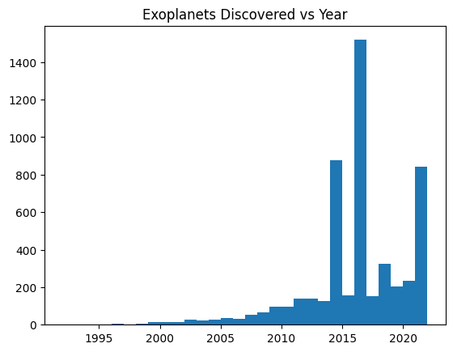

```python
plt.hist(df_no_dupe["disc_year"], bins=sorted(df_no_dupe["disc_year"].unique()))
plt.title("Exoplanets Discovered vs Year")
plt.show()
```

There seems to be a steady trend of increased discoveries, with the exception of a few outlier years. The outlier years between 2014 and 2020 are due to the Kepler space telescope being active during that period. NASA announced large batches of discovered planets all at once during that period, which is the reason why some of these years are so much higher than the others.

Next, we can look at planet denisty versus planet radius. From a purely physics perspective, one would expect density to increase as radius increases; the planet experiences a compressive force as mass increases, so in order to maintain a larger radius, the planet must have a higher density to counteract that force. I will graph planet denisty versus radius, using both the with duplicates and no duplicates dataset. I use a log scale on both axes to make the results more clear.

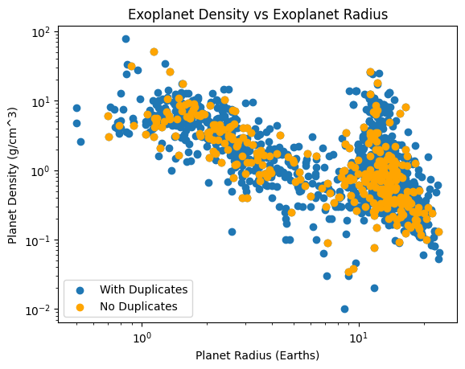

```python
plt.figure()
plt.title("Exoplanet Density vs Exoplanet Radius")
plt.scatter(df_nasa["pl_rade"], df_nasa["pl_dens"], c='tab:blue', label="With Duplicates")
plt.scatter(df_no_dupe["pl_rade"], df_no_dupe["pl_dens"], c='orange', label="No Duplicates")
plt.yscale('log')
plt.xscale('log')
plt.xlabel("Planet Radius (Earths)")
plt.ylabel("Planet Density (g/cm^3)")
plt.legend(loc='lower left')
plt.show()
```

This plot seems to defy our expectations! As the radius of the planet increases, the density decreases. In addition, two primary clusters can be observed in the points. This can be attributed to the difference between [rocky planets](https://en.wikipedia.org/wiki/Terrestrial_planet) and [gas giants](https://en.wikipedia.org/wiki/Gas_giant). Planets with a large radius tend to be gas giants, and their density is low. Conversely, small gas giants don't form (due to the gravity being too weak to hold the gas together), so smaller planets tend to be rocky, and thus have a higher density. The two clusters observed are rocky planets and gas giants.

Although it won't be completely accurate, we can try to apply K-means clustering to the data to apply rocky and gas giant labels to the planets. This could potentially be useful in future analysis. I will label the flag of whether or not the planet is a gas giant as 'pl_type'.

```python
# create training set (KMeans cannot handle NaN)
train = df_nasa.dropna(subset=["pl_rade", "pl_dens"])

# classify the planets
pl_type = KMeans(n_clusters=2, random_state=1).fit(np.c_[train["pl_rade"], train["pl_dens"]])
df_nasa["pl_type"] = list(map(lambda x : np.nan if any(pd.isna(x)) else pl_type.predict([x]),
                              np.c_[df_nasa["pl_rade"], df_nasa["pl_dens"]]))
```

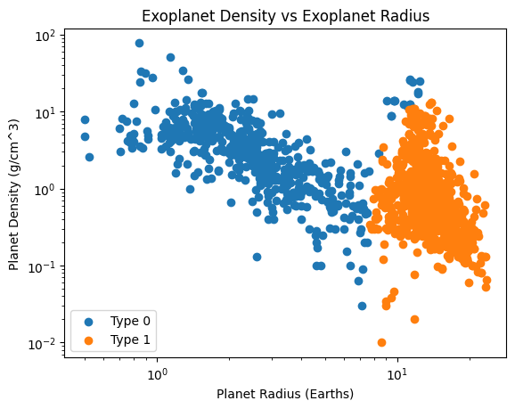

```python
# graph the results
plt.figure()
plt.title("Exoplanet Density vs Exoplanet Radius")
plt.scatter(df_nasa.loc[df_nasa["pl_type"] == 0, "pl_rade"], df_nasa.loc[df_nasa["pl_type"] == 0, "pl_dens"], c='tab:blue', label="Type 0")
plt.scatter(df_nasa.loc[df_nasa["pl_type"] == 1, "pl_rade"], df_nasa.loc[df_nasa["pl_type"] == 1, "pl_dens"], c='tab:orange', label="Type 1")
plt.yscale('log')
plt.xscale('log')
plt.xlabel("Planet Radius (Earths)")
plt.ylabel("Planet Density (g/cm^3)")
plt.legend(loc='lower left')
plt.show()
```

The clustering algorithm seems to have worked very well. Two distinct sets of planets are visible. This will be returned to later in the analysis.

Next, we can look at the relationship between the planet's equilibrium temperature and its maximum distance from its star. Here, the "semi-major axis" is a metric of the maximum distance the planet reaches from its star during its orbit. However, this graph uses the ratio of the semi-major axis to the radius of the star. The reason for this is because the semi-major axis measures distance to the center of the star, rather than the surface, and although star radius does not directly correspond to the heat flux produced, using the ratio metric produces a clearer relationship. I will put both axes on log scale to better show the relationship.

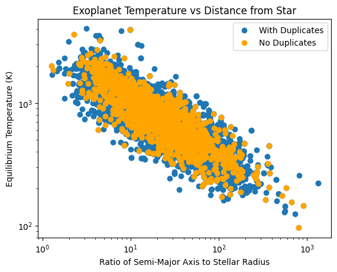

```python
plt.figure()
plt.title("Exoplanet Temperature vs Distance from Star")
plt.scatter(df_nasa["pl_ratdor"], df_nasa["pl_eqt"], c='tab:blue', label="With Duplicates")
plt.scatter(df_no_dupe["pl_ratdor"], df_no_dupe["pl_eqt"], c='orange', label="No Duplicates")
plt.xlabel("Ratio of Semi-Major Axis to Stellar Radius")
plt.ylabel("Equilibrium Temperature (K)")
plt.xscale('log')
plt.yscale('log')
plt.legend()
plt.show()
```

This graph is fairly straightforward. As the planet gets closer to the star, it gets hotter. This is a very reasonable and intuitive observation.

We can also look at the equilibrium temperature in terms of a histogram. I will use the no duplicates dataset here to avoid double counting.

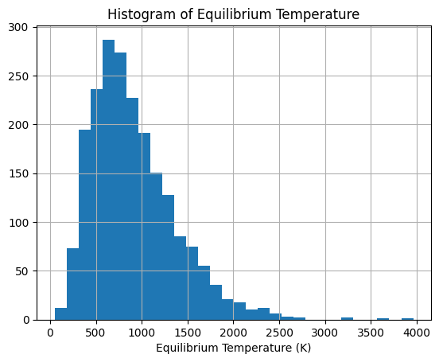

```python
df_no_dupe["pl_eqt"].hist(bins=30)
plt.title("Histogram of Equilibrium Temperature")
plt.xlabel("Equilibrium Temperature (K)")
plt.show()
```

Interestingly, there is a very clear Poisson distribution visible here, despite not being a time series. Most exoplanets seem to fall into the 500-1000K temperature range. Quite hot!

We can also look at the number of planets per system in the form of a histogram. To make the lower end more visible, I will plot the number of exoplanets on a log scale. I will use the dataset that only counts each system once so that a system with multiple planets is not counted many times.

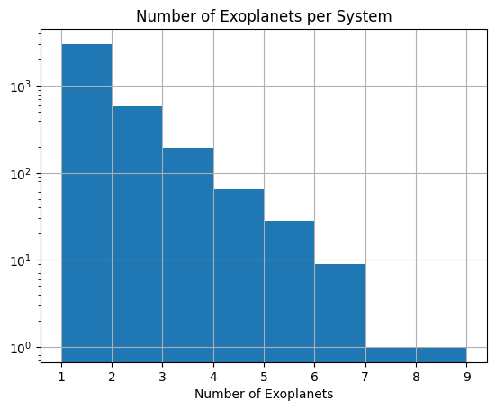

```python
df_sys["sy_pnum"].hist(bins=range(1, 10))
plt.title("Number of Exoplanets per System")
plt.xlabel("Number of Exoplanets")
plt.yscale('log')
plt.show()
```

We can see a very clear exponential distribution here. In fact, our solar system, which has 8 planets, seems to be very rare!

For fun, we can also make a galactic map. This map is not a very accurate projection because galactic latitude and longitude are measured in degrees rather than cartesian distances, but it's interesting to see nonetheless.

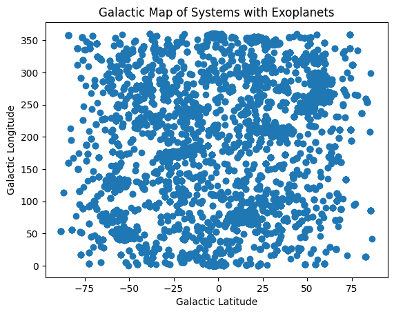

```python
plt.figure()
plt.title("Galactic Map of Systems with Exoplanets")
plt.scatter(df_nasa["glat"], df_nasa["glon"])
plt.xlabel("Galactic Latitude")
plt.ylabel("Galactic Longitude")
plt.show()
```

We can also look at the mass of exoplanets versus their orbital periods. To make the relationship more clear, I will graph both axes on log scale.

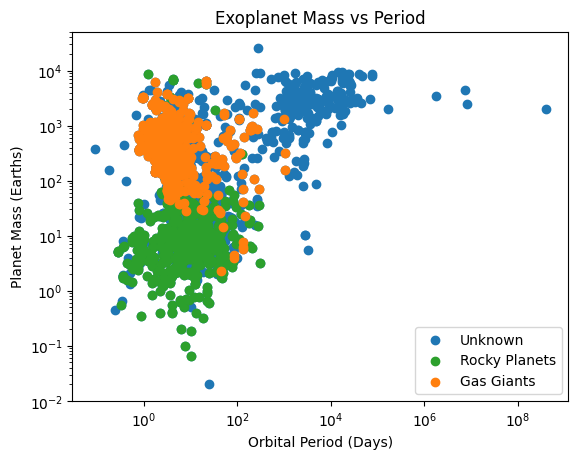

```python
plt.figure()
plt.title("Exoplanet Mass vs Period")
plt.scatter(df_nasa["pl_orbper"], df_nasa["pl_masse"], c='tab:blue', label="Unknown")
plt.scatter(df_nasa.loc[df_nasa["pl_type"] == 0, "pl_orbper"], df_nasa.loc[df_nasa["pl_type"] == 0, "pl_masse"], c='tab:green', label="Rocky Planets")
plt.scatter(df_nasa.loc[df_nasa["pl_type"] == 1, "pl_orbper"], df_nasa.loc[df_nasa["pl_type"] == 1, "pl_masse"], c='tab:orange', label="Gas Giants")
plt.xlabel("Orbital Period (Days)")
plt.ylabel("Planet Mass (Earths)")
plt.xscale('log')
plt.yscale('log')
plt.legend(loc='lower right')
plt.show()
```

There appears to be a relationship here, but it's not exactly clear what. It may be because gas giants, which tend to have the most mass, also tend to form in the outer part of systems, whereas rocky planets, which are not always very massive, tend to form in the inner system. More data would be needed to confirm (or reject) this hypothesis. In this project, I will not attempt to answer this question.

Lastly, we can also look at the correlation matrix for this dataset. This will not be very helpful for analysis, but it can give an idea of how cohesive the data is. To make the important values more visible, extraneous values such as flags, errors, and non-numerical values are not included in the matrix.

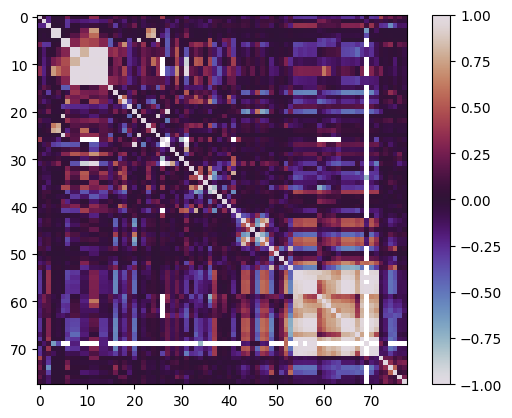

```python
df = df_nasa[df_nasa.columns.drop(list(df_nasa.filter(regex='flag|err|lim|ref|pub|method|locale|facility|date|name|_id|mnum')))]
plt.imshow(df.corr(numeric_only=True), cmap='twilight')
plt.colorbar()
plt.show()
```

# Examining Methods of Discovery

After observing and recording data from systems, various techniques can be used to discover the exoplanets within them. In this section, I will analyze the use cases and effectiveness of some of these techniques, and hopefully draw some conclusions about the usefulness of each.

First, we can look at the names of the methods in question, as well as how often they are used.

```python
df_nasa["discoverymethod"].value_counts()
```

```
Transit                          30802
Radial Velocity                   2270
Microlensing                       430
Transit Timing Variations          120
Imaging                            113
Eclipse Timing Variations           24
Orbital Brightness Modulation       20
Pulsar Timing                       12
Astrometry                           2
Pulsation Timing Variations          2
Disk Kinematics                      1
Name: discoverymethod, dtype: int64
```

It seems that the top five methods are much more popular than the rest. To ensure robustness of the analysis, I will only consider the top five methods to ensure that there will be enough data. Brief descriptions of the top five methods are as follows:

- The [transit](https://en.wikipedia.org/wiki/Transit_method) method involves observing the brightness of a star. When a planet passes in front of the star, the star's brightness will drop. By observing the frequency and size of these brightness dips, orbital period and planet size, among other things, can be determined.
- The [radial velocity](https://en.wikipedia.org/wiki/Methods_of_detecting_exoplanets#Radial_velocity) method (aka the Doppler method) involves monitoring the wavelength of the light emitted from a star. As a planet orbits around a star, the star can also be said to orbit around the planet. The slight adjustments in the star's position causes the wavelength of the light to undergo a Doppler shift as it oscillates between being closer and father from the Earth. In this way, exoplanets can be detected.
- [Gravitational microlensing](https://en.wikipedia.org/wiki/Methods_of_detecting_extrasolar_planets#Gravitational_microlensing) involves monitoring light as it lenses around a star. Massive objects can serve as a 'gravitational lense', magnifying the light of objects behind it by warping the space around it. Small fluctuations in the magnifying effect of the gravitational lense can be used to detect the influence of exoplanets.
- [Transit Timing Variations (TTV)](https://en.wikipedia.org/wiki/Methods_of_detecting_exoplanets#Transit_timing) is a bit different from the other methods in that it involves the measurement of a known exoplanet. By measuring the variation in period of a known exoplanet, it is possible to deduce the existance of others based on how it is affected.
- [Direct imaging](https://en.wikipedia.org/wiki/Methods_of_detecting_exoplanets#Direct_imaging) is exactly what it sounds like. But because stars are much brighter than planets, a planet must be significantly seperated from its host star and also very large in order to be detected in this way.

To make analysis easier, I will create a new dataframe that drops all entries besides for the described methods. I will also relabel Transit Timing Variations as TTV for readability purposes.

```python
df_methods = df_nasa[  (df_nasa['discoverymethod'] == 'Transit')
                     | (df_nasa['discoverymethod'] == 'Radial Velocity')
                     | (df_nasa['discoverymethod'] == 'Microlensing')
                     | (df_nasa['discoverymethod'] == 'Transit Timing Variations')
                     | (df_nasa['discoverymethod'] == 'Imaging')].copy()

# 'Transit Timing Variations' is kind of long for a label, so abbreviate it
df_methods['discoverymethod'] = df_methods['discoverymethod'].apply(lambda x : 'TTV' if x == 'Transit Timing Variations' else x)

df_methods.head()
```

| rowid | pl_name | hostname | pl_letter | hd_name | hip_name | tic_id | gaia_id | default_flag | sy_snum | sy_pnum | ... | rowupdate | pl_pubdate | releasedate | pl_nnotes | st_nphot | st_nrvc | st_nspec | pl_nespec | pl_ntranspec | pl_type |
| --- | --- | --- | --- | --- | --- | --- | --- | --- | --- | --- | --- | --- | --- | --- | --- | --- | --- | --- | --- | --- | --- |
| 1 | 11 Com b | 11 Com | b | HD 107383 | HIP 60202 | TIC 72437047 | Gaia DR2 3946945413106333696 | True | 2 | 1 | ... | 2014-05-14 | 2008-01 | 2014-05-14 | 2.0 | 1.0 | 2.0 | 0.0 | 0.0 | 0.0 | NaN |
| 2 | 11 Com b | 11 Com | b | HD 107383 | HIP 60202 | TIC 72437047 | Gaia DR2 3946945413106333696 | False | 2 | 1 | ... | 2014-07-23 | 2011-08 | 2014-07-23 | 2.0 | 1.0 | 2.0 | 0.0 | 0.0 | 0.0 | NaN |
| 3 | 11 UMi b | 11 UMi | b | HD 136726 | HIP 74793 | TIC 230061010 | Gaia DR2 1696798367260229376 | False | 1 | 1 | ... | 2018-04-25 | 2009-10 | 2014-05-14 | 0.0 | 1.0 | 1.0 | 0.0 | 0.0 | 0.0 | NaN |
| 4 | 11 UMi b | 11 UMi | b | HD 136726 | HIP 74793 | TIC 230061010 | Gaia DR2 1696798367260229376 | False | 1 | 1 | ... | 2018-04-25 | 2011-08 | 2014-07-23 | 0.0 | 1.0 | 1.0 | 0.0 | 0.0 | 0.0 | NaN |
| 5 | 11 UMi b | 11 UMi | b | HD 136726 | HIP 74793 | TIC 230061010 | Gaia DR2 1696798367260229376 | True | 1 | 1 | ... | 2018-09-04 | 2017-03 | 2018-09-06 | 0.0 | 1.0 | 1.0 | 0.0 | 0.0 | 0.0 | NaN |

5 rows × 287 columns

I will begin by making some graphs to identify what types of objects the methods tend to detect. In the above descriptions of the methods, I mention the variables that each method uses to identify exoplanets. Because they are directly important to the detection methods, I will focus on them for the analysis. In summary, the variables are: orbital period, radius, mass, and number of planets. In addition, orbital inclination is another important variable because many of these methods depend on the exoplanet being in the plane of the Earth and host star.

First, I will look at orbital period and orbital period error.

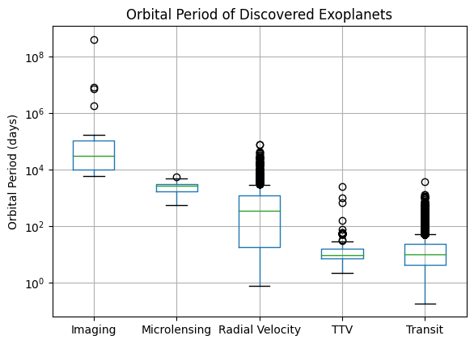

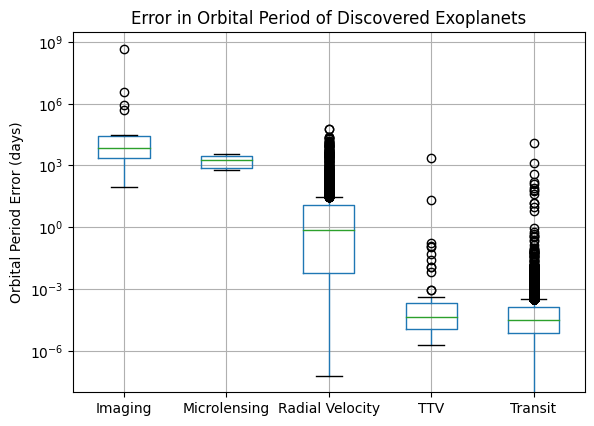

```python
# orbital period
df_methods.boxplot(column='pl_orbper', by='discoverymethod')
plt.suptitle("")
plt.title("Orbital Period of Discovered Exoplanets")
plt.ylabel("Orbital Period (days)")
plt.xlabel("")
plt.yscale('log')
plt.show()

# orbital period error
df_methods.boxplot(column='pl_orbpererr1', by='discoverymethod')
plt.suptitle("")
plt.title("Error in Orbital Period of Discovered Exoplanets")
plt.ylabel("Orbital Period Error (days)")
plt.xlabel("")
plt.yscale('log')
plt.show()
```

Imaging and microlensing seem to exclusively capture exoplanets with a very large period. For imaging, this is in line with expectations because a large period also means a far out orbit, which is one of the requirements for detection by this method. For microlensing, the reasoning is not so apparent. It could possibly be due to gravitational lensing being a weak effect, and for a planet to affect it in a noticable way, it needs to take a large orbit to move the center of mass of its system. Radial velocity seems to be able to detect planets of all periods. TTV and transit seem to detect primarily those with lower periods. This is likely due to both methods requiring the brightness of a star to be recorded over a long period of time. Planets that pass in front of the star frequently (aka those with shorter periods) may be more likely to be detected through these methods.

For the error plot, TTV and transit seem to have the best error. Based on both distributions, the error for these two methods seems to be about 0.001%. The other methods do not see such remarkable precision, with the error ranging between 10% and 0.1%.

Next, let's look at planet radius and its error.

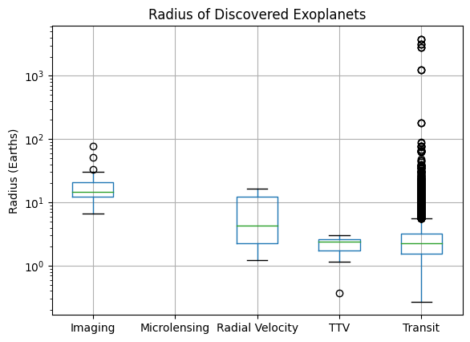

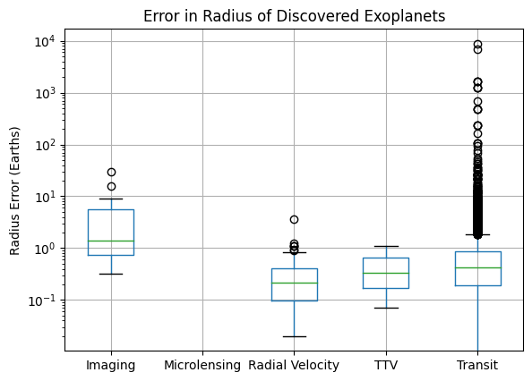

```python
# radius
df_methods.boxplot(column='pl_rade', by='discoverymethod')
plt.suptitle("")
plt.title("Radius of Discovered Exoplanets")
plt.ylabel("Radius (Earths)")
plt.xlabel("")
plt.yscale('log')
plt.show()

# radius error
df_methods.boxplot(column='pl_radeerr1', by='discoverymethod')
plt.suptitle("")
plt.title("Error in Radius of Discovered Exoplanets")
plt.ylabel("Radius Error (Earths)")
plt.xlabel("")
plt.yscale('log')
plt.show()
```

For this feature, microlensing is absent because no direct observations of the exoplanet are made. It seems that transit is able to detect planets with much lower radii than any of the other methods. In addition, transit also seems to be able to detect planets with very large radii. Imaging seems to require planets to have a larger radius, which is expected. Radial velocity seems to bridge the gap between imaging and transit in terms of radii it tends to detect.

All methods seem to give the same 10% error, so there is not much to say here.

Next, let's look at planet mass.

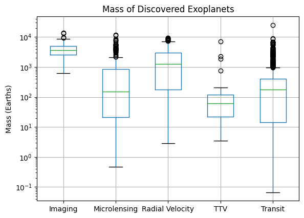

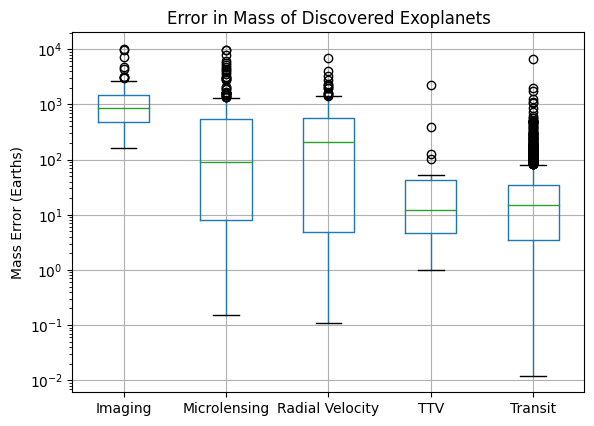

```python
# mass
df_methods.boxplot(column='pl_masse', by='discoverymethod')
plt.suptitle("")
plt.title("Mass of Discovered Exoplanets")
plt.ylabel("Mass (Earths)")
plt.xlabel("")
plt.yscale('log')
plt.show()

# mass error
df_methods.boxplot(column='pl_masseerr1', by='discoverymethod')
plt.suptitle("")
plt.title("Error in Mass of Discovered Exoplanets")
plt.ylabel("Mass Error (Earths)")
plt.xlabel("")
plt.yscale('log')
plt.show()
```

Imaging seems to require a particularly high mass for detection; this is expected because imaging requires planets to be large for detection. Transit and microlensing seem to be the most flexible in terms of mass of detected planets; however it must be considered that microlensing produces a very large error (close to 100%) in the estimated mass of the planet, so the spread of masses measured does not represent the true spread of masses it can detect. Radial velocity and TTV also require somewhat higher masses, which is to be expected because both rely on the object of detection to gravitationally influence the movement of stars and planets respectively.

Except for microlensing which seems to have an exceedingly high error of near 100%, all the methods have an error of about 10%.

We can also look at the number of planets in the system detected. For this graph, it is important not to double count, since, for example, if a system were to have 8 planets, it would be counted 8 times (once for each planet entry). I take a different approach from the other graphs and remove not just duplicate planets, but duplicate systems.

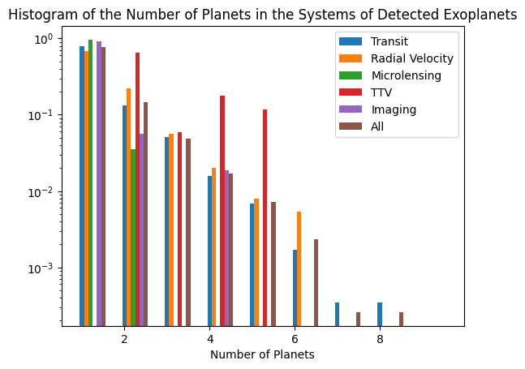

```python
# remove duplicate systems
df_pnum = df_methods.drop_duplicates(subset="hostname", keep="last")

# helper method for counting the number of planets
# we care more about the ratio of the types of planets, so normalize this quantity
def count_p(col):
    count = []
    total = df_pnum.loc[df_pnum["discoverymethod"] == col]["sy_pnum"].count()

    for i in range(1, 10):
        count.append(df_pnum.loc[(df_pnum["discoverymethod"] == col) & (df_pnum["sy_pnum"] == i)]["sy_pnum"].count() / total)

    return count

# helper method for counting the number of planets for all methods
def count_all():
    count = []
    total = df_pnum["sy_pnum"].count()

    for i in range(1, 10):
        count.append(df_pnum.loc[df_pnum["sy_pnum"] == i]["sy_pnum"].count() / total)

    return count

# helper method for getting the x location of each bar
def xloc(i):
    return [i * 0.1 + j for j in range(1, 10)]

# graph number of planets
plt.figure()
plt.bar(xloc(0), count_p("Transit"), width=0.1, label="Transit")
plt.bar(xloc(1), count_p("Radial Velocity"), width=0.1, label="Radial Velocity")
plt.bar(xloc(2), count_p("Microlensing"), width=0.1, label="Microlensing")
plt.bar(xloc(3), count_p("TTV"), width=0.1, label="TTV")
plt.bar(xloc(4), count_p("Imaging"), width=0.1, label="Imaging")
plt.bar(xloc(5), count_all(), width=0.1, label="All")

plt.title('Histogram of the Number of Planets in the Systems of Detected Exoplanets')
plt.xlabel('Number of Planets')
plt.yscale('log')
plt.legend()
plt.show()
```

Lastly, we can look at the inclination of planets detected.

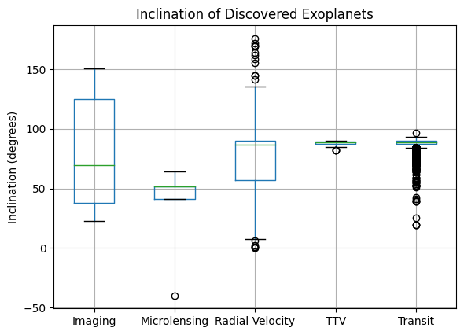

```python
# inclination
df_methods.boxplot(column='pl_orbincl', by='discoverymethod')
plt.suptitle("")
plt.title("Inclination of Discovered Exoplanets")
plt.ylabel("Inclination (degrees)")
plt.xlabel("")
plt.show()
```

In terms of inclination, imaging and radial velocity seem to be the most flexible with what can be detected. TTV and transit on the other hand both seem to require the planets to be almost exactly in-plane for the detection to work. Microlensing also seems to have a somewhat narrow requirement for what it can detect.

Overall, transit is the most effective of the methods. For orbital period, radius, mass, and number of planets, it is able to detect a very large range of values with good precision. The one shortcoming is that this method requires a very specific inclination of a planet in order for it to be detectable. Because transit is the method used for the vast majority of exoplanet discoveries, it is likely that a lot of exoplanets are being missed for not being exactly in-plane. In that regard, more detection via radial velocity would likely turn up good results. In terms of detection range, it is second only to transit, and in terms of inclination it is the most flexible out of all the methods. Therefore, I believe that more comprehensive data on exoplanets could be gathered via the radial velocity method.

# Relating Stars and Planets

In this section, I examine how host stars and their planets are related. This is somewhat of a broad statement, so I will narrow down the scope to one idea. Just from intuition, one interesting relation between host stars and planets is material composition. In other words, if we know what the star is made of, can we predict what possible planets are made of? Stars are much easier to measure than exoplanets, so being able to deduce the properties of exoplanets from their host stars would be a useful tool. The specific quantities of focus are planet density and gas giant vs rocky classification.

Before training any models, let's try to tease out information visually with graphs and linear regression. Note: one planet can have multiple entries, but because quantities vary between entries and there is no way to identify which is the "correct" measurement (if any), I will treat each entry as its own exoplanet.

First, we will look at something straightfoward: star density and planet density. Because planets will form from the materials that gather around stars, it is not unlikely that similar materials go into each.

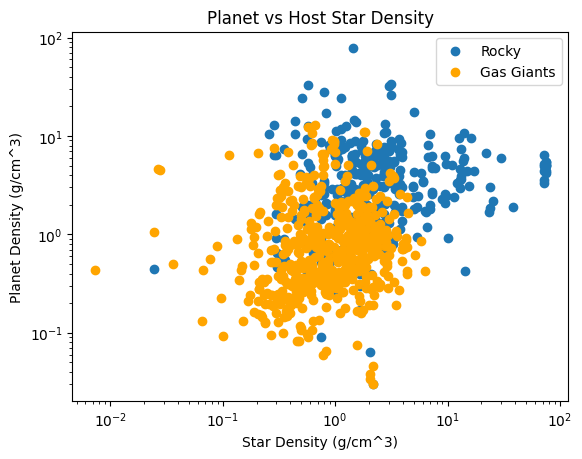

```python
plt.figure()
plt.title("Planet vs Host Star Density")

# seperate gas giants and rocky planets
plt.scatter(df_nasa.loc[df_nasa["pl_type"] == 0, "st_dens"], df_nasa.loc[df_nasa["pl_type"] == 0, "pl_dens"], label='Rocky')
plt.scatter(df_nasa.loc[df_nasa["pl_type"] == 1, "st_dens"], df_nasa.loc[df_nasa["pl_type"] == 1, "pl_dens"], c='orange', label='Gas Giants')

# log scale makes it easier to see the relationship
plt.xscale('log')
plt.yscale('log')

plt.xlabel("Star Density (g/cm^3)")
plt.ylabel("Planet Density (g/cm^3)")
plt.legend()
plt.show()
```

A couple interesting things can be noted about this graph. First, there does seem to be a clear relationship between planet density and star denisty. Second, not only do gas giants and rocky planets seem to follow distributions, less dense stars seem to have only gas giants and more dense stars seem to have only rocky planets! Let's see if fitting a regression line to each population yields more information. Because there are a lot of outliers in this dataset and Sklearn's LinearRegression is sensitive to this, I will weight the points by the inverse of their z-score.

```python
# first, drop NaN values
train = df_nasa.dropna(subset=["st_dens", "pl_dens"]).copy()

# helper function for calculating the weights
def weight(x):
     return list(map(lambda x : 1 / x**2, zscore(x)))

# (need to use zip on all the inputs because fit() expects the array to look like [[1], [2], [3], ...])
def form(x):
    return list(zip(np.log(x)))

# linear regression on the whole population
gen_reg = LinearRegression().fit(form(train["st_dens"]),
                                 np.log(train["pl_dens"]),
                                 sample_weight=weight(train["st_dens"]))

# print the score of the model
print("General Score:", gen_reg.score(form(train["st_dens"]),
                                      np.log(train["pl_dens"]),
                                      sample_weight=weight(train["st_dens"])))
print(gen_reg.coef_, gen_reg.intercept_)

# linear regression on gas giant population
gasg_reg = LinearRegression().fit(form(train.loc[train["pl_type"] == 1, "st_dens"]),
                                  np.log(train.loc[train["pl_type"] == 1, "pl_dens"]),
                                  sample_weight=weight(np.log(train.loc[train["pl_type"] == 1, "st_dens"])))

# print the score of the model
print("Gas Giant Score:", gasg_reg.score(form(train.loc[train["pl_type"] == 1, "st_dens"]),
                                         np.log(train.loc[train["pl_type"] == 1, "pl_dens"]),
                                         sample_weight=weight(train.loc[train["pl_type"] == 1, "st_dens"])))
print(gasg_reg.coef_, gasg_reg.intercept_)

# linear regression on rocky population
rocky_reg = LinearRegression().fit(form(train.loc[train["pl_type"] == 0, "st_dens"]),
                                   np.log(train.loc[train["pl_type"] == 0, "pl_dens"]),
                                   sample_weight=weight(train.loc[train["pl_type"] == 0, "st_dens"]))

# print the score of the model
print("Rocky Score:", rocky_reg.score(form(train.loc[train["pl_type"] == 0, "st_dens"]),
                                      np.log(train.loc[train["pl_type"] == 0, "pl_dens"]),
                                      sample_weight=weight(train.loc[train["pl_type"] == 0, "st_dens"])))
print(rocky_reg.coef_, rocky_reg.intercept_)
```

```
General Score: 1.816389240572036e-06
[0.64341825] -0.46997115733456685
Gas Giant Score: -0.003880859713508489
[0.61440651] -0.4165106523900327
Rocky Score: 1.3247796609161533e-05
[0.00521536] 1.0918545230136072
```

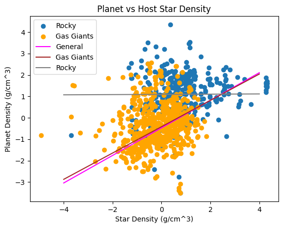

```python
# plot the regression
# it's hard to plot lines on log scale, so log during scatter instead
plt.figure()
plt.title("Planet vs Host Star Density")

# seperate gas giants and rocky planets
plt.scatter(np.log(df_nasa.loc[df_nasa["pl_type"] == 0, "st_dens"]),
            np.log(df_nasa.loc[df_nasa["pl_type"] == 0, "pl_dens"]), label='Rocky')
plt.scatter(np.log(df_nasa.loc[df_nasa["pl_type"] == 1, "st_dens"]),
            np.log(df_nasa.loc[df_nasa["pl_type"] == 1, "pl_dens"]), c='orange', label='Gas Giants')

# plot the regression lines
plt.plot([-4, 0 , 4], gen_reg.predict([[-4], [0], [4]]), label='General', c='magenta')
plt.plot([-4, 0 , 4], gasg_reg.predict([[-4], [0], [4]]), label='Gas Giants', c='brown')
plt.plot([-4, 0 , 4], rocky_reg.predict([[-4], [0], [4]]), label='Rocky', c='gray')

plt.xlabel("Star Density (g/cm^3)")
plt.ylabel("Planet Density (g/cm^3)")
plt.legend()
plt.show()
```

It seems that gas giants are more closely related to the star's composition than rocky planets. This makes sense since the lighter elements that make up stars tend to be gasses. Nonetheless, the fits are not as good as I was hoping for. It looks like that even with accounting for outliers in star density, outliers in planet density are still throwing off the regression. However, this is fine for now. I will fit a model predicting density using more than just star density a bit later in the analysis.

Next, let's look at something less intuitive: planet density vs star radius. These two quantities might sound independent, but by graphing the two, a slight relationship becomes visible.

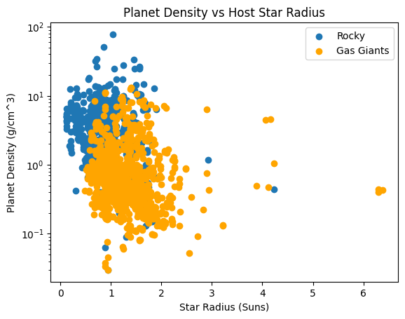

```python
plt.figure()
plt.title("Planet Density vs Host Star Radius")

# seperate gas giants and rocky planets
plt.scatter(df_nasa.loc[df_nasa["pl_type"] == 0, "st_rad"], df_nasa.loc[df_nasa["pl_type"] == 0, "pl_dens"], label='Rocky')
plt.scatter(df_nasa.loc[df_nasa["pl_type"] == 1, "st_rad"], df_nasa.loc[df_nasa["pl_type"] == 1, "pl_dens"], label='Gas Giants', c='orange')

# make it easier to see trends
plt.yscale('log')

plt.xlabel("Star Radius (Suns)")
plt.ylabel("Planet Density (g/cm^3)")
plt.legend()
plt.show()
```

Again, we can try to use linear regression. This time, I will not do seperate regressions for gas giants and rocky planets. I will still weight by inverse z-score.

```python
# first, drop NaN values
train = df_nasa.dropna(subset=["st_rad", "pl_dens"]).copy()

# helper function for calculating the weights
def weight(x):
     return list(map(lambda x : 1 / x**2, zscore(x)))

# (need to use zip on all the inputs because fit() expects the array to look like [[1], [2], [3], ...])
def form(x):
    return list(zip(x))

# linear regression on the whole population
reg = LinearRegression().fit(form(train["st_rad"]),
                             np.log(train["pl_dens"]),
                             sample_weight=weight(train["st_rad"]))

# print the score of the model
print("Score:", reg.score(form(train["st_rad"]),
                np.log(train["pl_dens"]),
                sample_weight=weight(train["st_rad"])))
print(gen_reg.coef_, gen_reg.intercept_)
```

[output not shown]

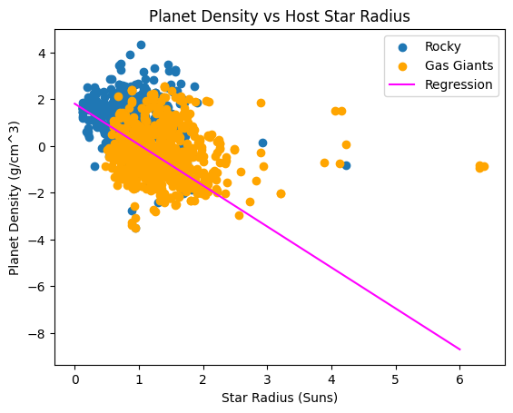

```python
plt.figure()
plt.title("Planet Density vs Host Star Radius")

# seperate gas giants and rocky planets
plt.scatter(df_nasa.loc[df_nasa["pl_type"] == 0, "st_rad"], np.log(df_nasa.loc[df_nasa["pl_type"] == 0, "pl_dens"]), label='Rocky')
plt.scatter(df_nasa.loc[df_nasa["pl_type"] == 1, "st_rad"], np.log(df_nasa.loc[df_nasa["pl_type"] == 1, "pl_dens"]), label='Gas Giants', c='orange')

# plot the regression line
plt.plot([0, 3, 6], reg.predict([[0], [3], [6]]), label='Regression', c='magenta')

plt.xlabel("Star Radius (Suns)")
plt.ylabel("Planet Density (g/cm^3)")
plt.legend()
plt.show()
```

This fit looks fairly good, although it does not make perfect physical sense. There is still a lot of variance in the data which is keeping the score low, but it does visually respect the input data. The one problem is that as star radius gets to the point where there is not a lot of data (past 2 suns), the density drops to physically unrealistic levels. There might be a way to correct this model, however there is a lack of data for larger stars.

Lastly, although I will not try to use regression on this quantity, we will look at planet density versus star temperature.

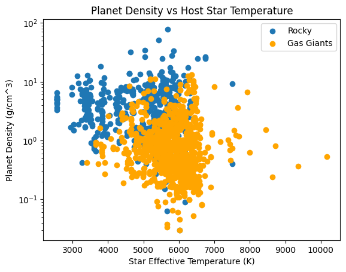

```python
plt.figure()
plt.title("Planet Density vs Host Star Temperature")

# seperate gas giants and rocky planets
plt.scatter(df_nasa.loc[df_nasa["pl_type"] == 0, "st_teff"], df_nasa.loc[df_nasa["pl_type"] == 0, "pl_dens"], label='Rocky')
plt.scatter(df_nasa.loc[df_nasa["pl_type"] == 1, "st_teff"], df_nasa.loc[df_nasa["pl_type"] == 1, "pl_dens"], label='Gas Giants', c='orange')

# make it easier to see trends
plt.yscale('log')

plt.xlabel("Star Effective Temperature (K)")
plt.ylabel("Planet Density (g/cm^3)")
plt.legend()
plt.show()
```

Here, although there is still large variance, there is a general decreasing trend visible between planet density and star temperature. It also seems that gas giants occur more around hotter stars.

Now that some basic analysis has been done, I will now train a model to classify whether a star is more likely to have rocky planets or gas giants. These are not mutually exclusive options, but if the model does better than random guessing, it will show some insight into how stars and planets form. The quantities the model will look at are: star temperature, star radius, star mass, star metallicity, star luminosity, star age, and star density.

First, I will benchmark random guessing.

```python
# first, create the dataset to be used for the models
train = df_nasa.dropna(subset=["pl_type", "st_teff", "st_rad", "st_mass", "st_met", "st_lum", "st_age", "st_dens"]).copy()
train["pl_type"] = train["pl_type"].astype(int)

# this is a helper function for grouping the input data because it is quite a long line
def data():
    return np.c_[train["st_teff"], train["st_rad"], train["st_mass"], train["st_met"],
                 train["st_lum"], train["st_age"], train["st_dens"]]

# probability of a given planet being a gas giant
print(train.loc[df_nasa["pl_type"] == 1, "pl_type"].count() / train["pl_type"].count())
```

```
0.6411960132890365
```

If the model can beat 65% accuracy, it is better than random guessing.

Next, I will try to train both a random forest model and LDA model. I will use 10 fold cross validation for these models, and I will use accuracy as my metric because I want correct results, but I do not prefer either a 'gas giant' result or 'rocky' result.

```python
# for the first model, train a random forest (perform 10-fold cross validation)
forest = RandomForestClassifier(n_estimators=30, max_depth=4)
scores = cross_validate(forest, data(), train["pl_type"], cv=10, scoring=['accuracy', 'neg_mean_squared_error'])
print("Accuracy:", scores['test_accuracy'].mean())
print("Error:", scores['test_neg_mean_squared_error'].mean())
```

```
Accuracy: 0.7640860215053763
Error: -0.23591397849462367
```

```python
# for the second model, use Linear Discriminant Analysis (perform 10-fold cross validation)
lda = LinearDiscriminantAnalysis()
scores = cross_validate(lda, data(), train["pl_type"], cv=10, scoring=['accuracy', 'neg_mean_squared_error'])
print("Accuracy:", scores['test_accuracy'].mean())
print("Error:", scores['test_neg_mean_squared_error'].mean())
```

```
Accuracy: 0.7701075268817206
Error: -0.22989247311827957
```

```python
# look closer at the random forest
# (have to retrain because the cross validation does not actually modify my instance of the forest model)
forest.fit(data(), train["pl_type"])
print(list(zip(["st_teff", "st_rad", "st_mass", "st_met", "st_lum", "st_age", "st_dens"], forest.feature_importances_)))
```

```
[('st_teff', 0.1284859855351104), ('st_rad', 0.07678909755993352), ('st_mass', 0.2932972317198219), ('st_met', 0.17586973473208417), ('st_lum', 0.14460940744272957), ('st_age', 0.09877581002518167), ('st_dens', 0.08217273298513877)]
```

Not only were both models able to beat random guessing, but they were able to achieve near 80% accuracy. This is a clear indicator that there is a relationship between host star and planet type. Looking closer at the random forest classifier, it turns out that the star mass, star metallicity, and star luminocity are the most important for determining the type of planet the star is most likely to have.

Next, using the same parameters, I will train a model that attempts to directly determine the density of the planet. For this, I will also perform 10 fold cross validation, though my metric will now be RMS error. For these models, I will benchmark them against the average measurement error in the density, however I do not expect the models to outperform this.

```python
# benchmark of average measurement error
print(train["pl_denserr1"].mean())
```

```
0.5128348096885813
```

```python
# for the first model, use linear regression (perform 10-fold cross validation)
reg = LinearRegression()
scores = cross_validate(reg, data(), train["pl_dens"], cv=10, scoring='neg_root_mean_squared_error')
print("RMS Error:", scores['test_score'].mean())
```

```
RMS Error: -2.8146094275874716
```

```python
# for the second model, use SVM (perform 10-fold cross validation)
svm = SVR()
scores = cross_validate(svm, data(), train["pl_dens"], cv=10, scoring='neg_root_mean_squared_error')
print("RMS Error:", scores['test_score'].mean())
```

```
RMS Error: -2.9274316529650846
```

```python
# look closer at the linear regression model
# (have to retrain because the cross validation does not actually modify my instance)
reg.fit(data(), train["pl_dens"])
print(list(zip(["st_teff", "st_rad", "st_mass", "st_met", "st_lum", "st_age", "st_dens"], reg.coef_)))
```

```
[('st_teff', -7.009902881293395e-05), ('st_rad', -0.4834696402146217), ('st_mass', -0.21716540942879436), ('st_met', -1.0915069551298986), ('st_lum', -0.11370716067907725), ('st_age', 0.02118454316354451), ('st_dens', 0.14984826419312447)]
```

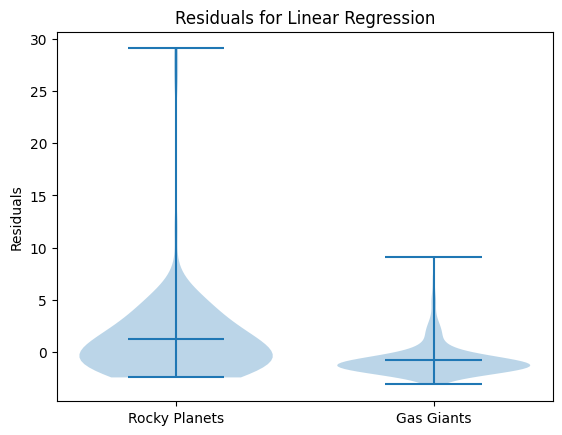

```python
# calculate residuals
train["predict"] = reg.predict(data())
train["resid"] = train["pl_dens"] - train["predict"]

# graph residuals of the linear regression on a a violin plot
fig, ax = plt.subplots()

# seperate into rocky planet and gas giant residuals
resid = train.groupby("pl_type")["resid"].apply(list).reset_index()
ax.violinplot(resid["resid"], list(resid["pl_type"]), widths=0.75, showmeans=True)

ax.set_xticks([0, 1], ['Rocky Planets', 'Gas Giants'])

ax.set_ylabel("Residuals")
ax.set_title("Residuals for Linear Regression")
plt.show()
```

The models both seem to have an error of around 3, which is much larger than the average measurement error of 0.5. Considering that most densities are around 1 g/cm^3, an error of 3 is very large. Looking at the residuals, the model seems to perform much better when only considering gas giants. However overall, I would consider these models to be ineffective. I believe the reason that this failed is because of the multiple entries per planet. Even though each entry shares the same star data, the planet data is not necessarily in agreement with the previous entry. This means that there is a non-linearity in the data that cannot be predicted by the model. Thus, in order to create a better model, better astronomical data is needed. Lastly, according to the linear regression model, star metallicity, radius, and mass are the three largest factors towards predicting planet density.

# Conclusions

In this project, I used K-Means clustering to create a tentative labeling of gas giants and rocky planets. I then analyzed the qualities of different exoplanet detection methods and drew relationships between host stars and their exoplanets.

I found that the two most effective methods of exoplanet detection are transit and radial velocity. However, transit is restricted in detection by orbital inclination. Because transit is being used for the vast majority of detections, there is scientific merit to increasing the use of radial velocity detection in order to create a more diverse dataset that is not so dependent on inclination.

I also found that it is possible to predict with good accuracy whether a star is more likely to have a rocky planet or gas giant planet. I trained both a random forest and LDA model, and found that they reached 80% accuracy in prediction, whereas random guessing would only achieve 65%. I found that star mass, star metallicity, and star luminocity are the most important features when determining what type of planets a star is likely to have.

I found that predicting planet density based on the star is a difficult problem. I found visible relations between multiple features (star density, radius, and temperature) and planet density, but due to non-linearity in the data, the accuracy of the models suffered. I trained both a linear regression and SVM model to predict planet density from star features. I found that the model suffered at predicting the density of rocky planets, but it performed much better for gas giants. I also found that star metallicity, star radius, and star mass are the most influential features towards determining planet density.